# Lab 2 Avacado Prices

Github Repository: https://github.com/jonathan-cleave/GSB-544-.git

# 0. Importing Data

```python
import numpy as np
import plotnine
import pandas as pd
from plotnine import ggplot, aes, geom_boxplot,geom_jitter,labs,geom_bar, position_stack, scale_fill_brewer, scale_y_continuous, element_text, geom_col, facet_wrap, theme, scale_fill_manual, scale_x_continuous
```

```python
df = pd.read_csv("C:/Users/jonat/Documents/Calpoly MSBA/Fall/Machine Learning 544/Data/avocado-updated-2020.csv")

df.head()
```

|  | date | average_price | total_volume | 4046 | 4225 | 4770 | total_bags | small_bags | large_bags | xlarge_bags | type | year | geography |
| --- | --- | --- | --- | --- | --- | --- | --- | --- | --- | --- | --- | --- | --- |
| 0 | 2015-01-04 | 1.22 | 40873.28 | 2819.50 | 28287.42 | 49.90 | 9716.46 | 9186.93 | 529.53 | 0.00 | conventional | 2015 | Albany |
| 1 | 2015-01-04 | 1.79 | 1373.95 | 57.42 | 153.88 | 0.00 | 1162.65 | 1162.65 | 0.00 | 0.00 | organic | 2015 | Albany |
| 2 | 2015-01-04 | 1.00 | 435021.49 | 364302.39 | 23821.16 | 82.15 | 46815.79 | 16707.15 | 30108.64 | 0.00 | conventional | 2015 | Atlanta |
| 3 | 2015-01-04 | 1.76 | 3846.69 | 1500.15 | 938.35 | 0.00 | 1408.19 | 1071.35 | 336.84 | 0.00 | organic | 2015 | Atlanta |
| 4 | 2015-01-04 | 1.08 | 788025.06 | 53987.31 | 552906.04 | 39995.03 | 141136.68 | 137146.07 | 3990.61 | 0.00 | conventional | 2015 | Baltimore/Washington |

```python
df.dtypes
df["geography"].unique()
```

```
array(['Albany', 'Atlanta', 'Baltimore/Washington', 'Boise', 'Boston',
       'Buffalo/Rochester', 'California', 'Charlotte', 'Chicago',
       'Cincinnati/Dayton', 'Columbus', 'Dallas/Ft. Worth', 'Denver',
       'Detroit', 'Grand Rapids', 'Great Lakes', 'Harrisburg/Scranton',
       'Hartford/Springfield', 'Houston', 'Indianapolis', 'Jacksonville',
       'Las Vegas', 'Los Angeles', 'Louisville', 'Miami/Ft. Lauderdale',
       'Midsouth', 'Nashville', 'New Orleans/Mobile', 'New York',
       'Northeast', 'Northern New England', 'Orlando', 'Philadelphia',
       'Phoenix/Tucson', 'Pittsburgh', 'Plains', 'Portland',
       'Raleigh/Greensboro', 'Richmond/Norfolk', 'Roanoke', 'Sacramento',
       'San Diego', 'San Francisco', 'Seattle', 'South Carolina',
       'South Central', 'Southeast', 'Spokane', 'St. Louis', 'Syracuse',
       'Tampa', 'Total U.S.', 'West', 'West Tex/New Mexico'], dtype=object)
```

# 1. Data Description

The avacado prices dataset includes the date, average price in $, total volumne of avacados, total bags and different types. Along with the type of avacado and where from. Some columns are categorical like geography and type, while most are numerical like avg price, bag numbers. Other less well known varaibles are 4046, 4225, 4770 which are numeric and represent the total number of avacados based on size values of PLU

# 2. Data Cleaning

```python
df_clean = df
df_clean.dropna()
df_clean.isna()
```

|  | date | average_price | total_volume | 4046 | 4225 | 4770 | total_bags | small_bags | large_bags | xlarge_bags | type | year | geography |
| --- | --- | --- | --- | --- | --- | --- | --- | --- | --- | --- | --- | --- | --- |
| 0 | False | False | False | False | False | False | False | False | False | False | False | False | False |
| 1 | False | False | False | False | False | False | False | False | False | False | False | False | False |
| 2 | False | False | False | False | False | False | False | False | False | False | False | False | False |
| 3 | False | False | False | False | False | False | False | False | False | False | False | False | False |
| 4 | False | False | False | False | False | False | False | False | False | False | False | False | False |
| ... | ... | ... | ... | ... | ... | ... | ... | ... | ... | ... | ... | ... | ... |
| 33040 | False | False | False | False | False | False | False | False | False | False | False | False | False |
| 33041 | False | False | False | False | False | False | False | False | False | False | False | False | False |
| 33042 | False | False | False | False | False | False | False | False | False | False | False | False | False |
| 33043 | False | False | False | False | False | False | False | False | False | False | False | False | False |
| 33044 | False | False | False | False | False | False | False | False | False | False | False | False | False |

33045 rows × 13 columns

```python
# changing names for PLU
df.rename(columns={'4046': "size_small", '4225': "size_large", "4770": 'size_xlarge'},inplace=True)

df_clean.head(5)
```

|  | date | average_price | total_volume | size_small | size_large | size_xlarge | total_bags | small_bags | large_bags | xlarge_bags | type | year | geography |
| --- | --- | --- | --- | --- | --- | --- | --- | --- | --- | --- | --- | --- | --- |
| 0 | 2015-01-04 | 1.22 | 40873.28 | 2819.50 | 28287.42 | 49.90 | 9716.46 | 9186.93 | 529.53 | 0.00 | conventional | 2015 | Albany |
| 1 | 2015-01-04 | 1.79 | 1373.95 | 57.42 | 153.88 | 0.00 | 1162.65 | 1162.65 | 0.00 | 0.00 | organic | 2015 | Albany |
| 2 | 2015-01-04 | 1.00 | 435021.49 | 364302.39 | 23821.16 | 82.15 | 46815.79 | 16707.15 | 30108.64 | 0.00 | conventional | 2015 | Atlanta |
| 3 | 2015-01-04 | 1.76 | 3846.69 | 1500.15 | 938.35 | 0.00 | 1408.19 | 1071.35 | 336.84 | 0.00 | organic | 2015 | Atlanta |
| 4 | 2015-01-04 | 1.08 | 788025.06 | 53987.31 | 552906.04 | 39995.03 | 141136.68 | 137146.07 | 3990.61 | 0.00 | conventional | 2015 | Baltimore/Washington |

```python
df_clean["geography"].value_counts()
```

```
geography
Albany                  612
Atlanta                 612
Baltimore/Washington    612
Boise                   612
Boston                  612
Buffalo/Rochester       612
California              612
Charlotte               612
Chicago                 612
Cincinnati/Dayton       612
Columbus                612
Dallas/Ft. Worth        612
Denver                  612
Detroit                 612
Grand Rapids            612
Great Lakes             612
Harrisburg/Scranton     612
Hartford/Springfield    612
Houston                 612
Indianapolis            612
Jacksonville            612
Las Vegas               612
Los Angeles             612
Louisville              612
Miami/Ft. Lauderdale    612
Midsouth                612
Nashville               612
New Orleans/Mobile      612
New York                612
Northeast               612
Northern New England    612
Orlando                 612
Philadelphia            612
Phoenix/Tucson          612
Pittsburgh              612
Plains                  612
Portland                612
Raleigh/Greensboro      612
Richmond/Norfolk        612
Roanoke                 612
Sacramento              612
San Diego               612
San Francisco           612
Seattle                 612
South Carolina          612
South Central           612
Southeast               612
Spokane                 612
St. Louis               612
Syracuse                612
Tampa                   612
Total U.S.              612
West                    612
West Tex/New Mexico     609
Name: count, dtype: int64
```

```python
# Creating major_regions

major_regions = {
    # Northeast
    'New York': 'Northeast',
    'Boston': 'Northeast',
    'Philadelphia': 'Northeast',
    'Hartford/Springfield': 'Northeast',
    'Buffalo/Rochester': 'Northeast',
    'Albany': 'Northeast',
    'Syracuse': 'Northeast',
    'Harrisburg/Scranton': 'Northeast',
    'Baltimore/Washington': 'Northeast',
    "Northen New England": "Northeast",
    "Northeast": "Northeast",

    # West
    'Los Angeles': 'West',
    'San Diego': 'West',
    'San Francisco': 'West',
    'Sacramento': 'West',
    'Portland': 'West',
    'Seattle': 'West',
    'Spokane': 'West',
    'Boise': 'West',
    'West Tex/New Mexico': 'West',
    'Las Vegas': 'West',
    'Phoenix/Tucson': 'West',
    'Denver': 'West',
    'California': 'West',
    'West': 'West',

    # Southeast
    'Miami/Ft. Lauderdale': 'Southeast',
    'Tampa': 'Southeast',
    'Orlando': 'Southeast',
    'Jacksonville': 'Southeast',
    'Atlanta': 'Southeast',
    'South Carolina': 'Southeast',
    'Raleigh/Greensboro': 'Southeast',
    'Charlotte': 'Southeast',
    'Richmond/Norfolk': 'Southeast',
    'Roanoke': 'Southeast',
    'Nashville': 'Southeast',
    'Louisville': 'Southeast',
    'New Orleans/Mobile': 'Southeast',
    'Southeast': 'Southeast',

    # South Central
    'Dallas/Ft. Worth': 'South Central',
    'Houston': 'South Central',
    'South Central': 'South Central',
    'New Orleans/Mobile': "South Central",
    "Midsouth": "South Central",

    # Great Lakes
    'Chicago': 'Great Lakes',
    'Detroit': 'Great Lakes',
    'Grand Rapids': 'Great Lakes',
    'Cincinnati/Dayton': 'Great Lakes',
    'Columbus': 'Great Lakes',
    'Cleveland': 'Great Lakes' if 'Cleveland' in df['geography'].unique() else None,
    'Indianapolis': 'Great Lakes',
    'Great Lakes': 'Great Lakes',

    # Plains
    'St. Louis': 'Plains',
    'Plains': 'Plains',

}

df_clean['major_regions'] = df_clean['geography'].map(major_regions)
df_clean.head(5)
```

|  | date | average_price | total_volume | size_small | size_large | size_xlarge | total_bags | small_bags | large_bags | xlarge_bags | type | year | geography | major_regions |
| --- | --- | --- | --- | --- | --- | --- | --- | --- | --- | --- | --- | --- | --- | --- |
| 0 | 2015-01-04 | 1.22 | 40873.28 | 2819.50 | 28287.42 | 49.90 | 9716.46 | 9186.93 | 529.53 | 0.00 | conventional | 2015 | Albany | Northeast |
| 1 | 2015-01-04 | 1.79 | 1373.95 | 57.42 | 153.88 | 0.00 | 1162.65 | 1162.65 | 0.00 | 0.00 | organic | 2015 | Albany | Northeast |
| 2 | 2015-01-04 | 1.00 | 435021.49 | 364302.39 | 23821.16 | 82.15 | 46815.79 | 16707.15 | 30108.64 | 0.00 | conventional | 2015 | Atlanta | Southeast |
| 3 | 2015-01-04 | 1.76 | 3846.69 | 1500.15 | 938.35 | 0.00 | 1408.19 | 1071.35 | 336.84 | 0.00 | organic | 2015 | Atlanta | Southeast |
| 4 | 2015-01-04 | 1.08 | 788025.06 | 53987.31 | 552906.04 | 39995.03 | 141136.68 | 137146.07 | 3990.61 | 0.00 | conventional | 2015 | Baltimore/Washington | Northeast |

```python
# metro regions

metro_regions = [
    'Albany','Atlanta','Baltimore/Washington','Boise','Boston','Buffalo/Rochester',
    'Charlotte','Chicago','Cincinnati/Dayton','Columbus','Dallas/Ft. Worth','Denver',
    'Detroit','Grand Rapids','Harrisburg/Scranton','Hartford/Springfield','Houston',
    'Indianapolis','Jacksonville','Las Vegas','Los Angeles','Louisville',
    'Miami/Ft. Lauderdale','Nashville','New Orleans/Mobile','New York','Orlando',
    'Philadelphia','Phoenix/Tucson','Pittsburgh','Portland','Raleigh/Greensboro',
    'Richmond/Norfolk','Roanoke','Sacramento','San Diego','San Francisco','Seattle',
    'Spokane','St. Louis','Syracuse','Tampa'
]

df_clean['metro_regions'] = df_clean['geography'].apply(lambda g: g if g in metro_regions else np.nan)

df_clean.reset_index()
df_clean
```

|  | date | average_price | total_volume | size_small | size_large | size_xlarge | total_bags | small_bags | large_bags | xlarge_bags | type | year | geography | major_regions | metro_regions |
| --- | --- | --- | --- | --- | --- | --- | --- | --- | --- | --- | --- | --- | --- | --- | --- |
| 0 | 2015-01-04 | 1.22 | 40873.28 | 2819.50 | 28287.42 | 49.90 | 9716.46 | 9186.93 | 529.53 | 0.00 | conventional | 2015 | Albany | Northeast | Albany |
| 1 | 2015-01-04 | 1.79 | 1373.95 | 57.42 | 153.88 | 0.00 | 1162.65 | 1162.65 | 0.00 | 0.00 | organic | 2015 | Albany | Northeast | Albany |
| 2 | 2015-01-04 | 1.00 | 435021.49 | 364302.39 | 23821.16 | 82.15 | 46815.79 | 16707.15 | 30108.64 | 0.00 | conventional | 2015 | Atlanta | Southeast | Atlanta |
| 3 | 2015-01-04 | 1.76 | 3846.69 | 1500.15 | 938.35 | 0.00 | 1408.19 | 1071.35 | 336.84 | 0.00 | organic | 2015 | Atlanta | Southeast | Atlanta |
| 4 | 2015-01-04 | 1.08 | 788025.06 | 53987.31 | 552906.04 | 39995.03 | 141136.68 | 137146.07 | 3990.61 | 0.00 | conventional | 2015 | Baltimore/Washington | Northeast | Baltimore/Washington |
| ... | ... | ... | ... | ... | ... | ... | ... | ... | ... | ... | ... | ... | ... | ... | ... |
| 33040 | 2020-11-29 | 1.47 | 1583056.27 | 67544.48 | 97996.46 | 2617.17 | 1414878.10 | 906711.52 | 480191.83 | 27974.75 | organic | 2020 | Total U.S. | NaN | NaN |
| 33041 | 2020-11-29 | 0.91 | 5811114.22 | 1352877.53 | 589061.83 | 19741.90 | 3790665.29 | 2197611.02 | 1531530.14 | 61524.13 | conventional | 2020 | West | West | NaN |
| 33042 | 2020-11-29 | 1.48 | 289961.27 | 13273.75 | 19341.09 | 636.51 | 256709.92 | 122606.21 | 134103.71 | 0.00 | organic | 2020 | West | West | NaN |
| 33043 | 2020-11-29 | 0.67 | 822818.75 | 234688.01 | 80205.15 | 10543.63 | 497381.96 | 285764.11 | 210808.02 | 809.83 | conventional | 2020 | West Tex/New Mexico | West | NaN |
| 33044 | 2020-11-29 | 1.35 | 24106.58 | 1236.96 | 617.80 | 1564.98 | 20686.84 | 17824.52 | 2862.32 | 0.00 | organic | 2020 | West Tex/New Mexico | West | NaN |

33045 rows × 15 columns

# 3. Most by Region

```python
df_3 = df_clean

# Filter Size, Year and Type
df_3 = df_3[(df_3["year"] == 2017) & (df_3["type"] =="organic")]
df_3

df_3 = df_3[["size_small","major_regions"]]

pd.set_option('display.float_format','{:.2f}'.format)
df_3 = df_3.groupby('major_regions')["size_small"].sum()
df_3 = df_3.sort_values(ascending=False).apply(lambda x: f"{x:,.2f}")

df_3
```

```
major_regions
West             5,826,061.33
South Central    2,786,158.76
Northeast        1,803,002.61
Southeast          545,476.80
Great Lakes        300,229.36
Plains             213,955.55
Name: size_small, dtype: object
```

West sold the most organic, small Hass avacados in 2017 with 5,826,061. This region includes California regions. (However based on different region grouping this number would change.)

# 4. Most by Month

```python
df_4 = df_clean

df['date'] =pd.to_datetime(df_4['date'])

df_4['month'] = df.date.dt.strftime("%b")
df_4['day'] = df_4['date'].dt.day
```

```python
pd.set_option('display.float_format','{:.2f}'.format)
df_4 = df_4.groupby("month",sort=False)["total_volume"].mean()
df_4 = df_4.apply(lambda x: f"{x:,.2f}")
df_4
```

```
month
Jan      985,312.16
Feb    1,095,373.83
Mar      995,715.04
Apr    1,016,581.69
May    1,123,632.25
Jun    1,051,246.57
Jul      983,268.10
Aug      949,924.93
Sep      906,477.26
Oct      844,686.29
Nov      822,347.02
Dec      807,669.47
Name: total_volume, dtype: object
```

The month of May has the highest average volume of avacado sales with 1,123,632.

# 5. Plot by Region

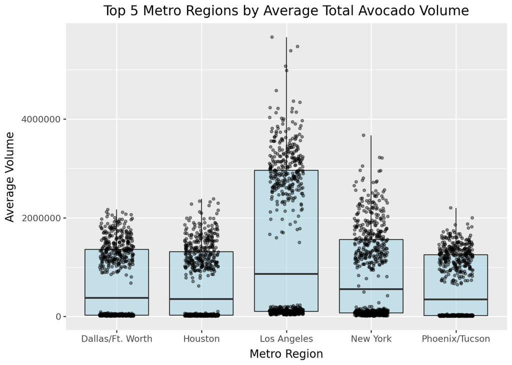

```python
df_5 = df_clean

pd.set_option('display.float_format','{:.2f}'.format)

top_5 = (df_5.groupby("metro_regions")["total_volume"].mean()).sort_values(ascending=False).head(5).index

df_top5 = df_5[df_5["metro_regions"].isin(top_5)]

(
ggplot(df_top5,aes(x="metro_regions",y="total_volume"))
+ geom_boxplot(outlier_shape=None,fill="lightblue",alpha=0.6)
+ geom_jitter(width=0.2,alpha=0.4,size=1)
+ labs(title="Top 5 Metro Regions by Average Total Avocado Volume",
        x="Metro Region",
        y="Average Volume"
    )
)
```

Based on the boxplot graph, Los angleles had the highest average volume, but also the largest range of values with a large amount of outliers shifting quartile 3 up.

# 6. CA Dataset

```python
df_ca = df_clean

ca_regions = [
"Los Angeles", "San Diego", "Sacramento", "San Francisco"
]

df_ca['california_regions'] = df_clean['geography'].apply(lambda g: g if g in ca_regions else np.nan)

df_ca = df_ca[df_ca["california_regions"].notna()]

df_ca["california_regions"].unique()

df_ca = df_ca.reset_index()

df_ca
```

|  | index | date | average_price | total_volume | size_small | size_large | size_xlarge | total_bags | small_bags | large_bags | xlarge_bags | type | year | geography | major_regions | metro_regions | month | day | california_regions |
| --- | --- | --- | --- | --- | --- | --- | --- | --- | --- | --- | --- | --- | --- | --- | --- | --- | --- | --- | --- |
| 0 | 44 | 2015-01-04 | 0.85 | 2682159.95 | 1837999.65 | 524430.47 | 64225.78 | 255504.05 | 215571.80 | 36981.72 | 2950.53 | conventional | 2015 | Los Angeles | West | Los Angeles | Jan | 4 | Los Angeles |
| 1 | 45 | 2015-01-04 | 1.25 | 54495.54 | 47721.51 | 1723.40 | 0.00 | 5050.63 | 5050.63 | 0.00 | 0.00 | organic | 2015 | Los Angeles | West | Los Angeles | Jan | 4 | Los Angeles |
| 2 | 80 | 2015-01-04 | 1.05 | 430138.88 | 110693.69 | 270107.61 | 9737.50 | 39600.08 | 39600.08 | 0.00 | 0.00 | conventional | 2015 | Sacramento | West | Sacramento | Jan | 4 | Sacramento |
| 3 | 81 | 2015-01-04 | 1.33 | 9213.49 | 3727.52 | 4327.52 | 0.00 | 1158.45 | 1158.45 | 0.00 | 0.00 | organic | 2015 | Sacramento | West | Sacramento | Jan | 4 | Sacramento |
| 4 | 82 | 2015-01-04 | 0.94 | 461607.33 | 244152.26 | 165299.33 | 15302.75 | 36852.99 | 30884.29 | 5595.00 | 373.70 | conventional | 2015 | San Diego | West | San Diego | Jan | 4 | San Diego |
| ... | ... | ... | ... | ... | ... | ... | ... | ... | ... | ... | ... | ... | ... | ... | ... | ... | ... | ... | ... |
| 2443 | 33018 | 2020-11-29 | 1.43 | 23531.38 | 3303.69 | 2057.03 | 0.00 | 18170.66 | 18144.54 | 26.12 | 0.00 | organic | 2020 | Sacramento | West | Sacramento | Nov | 29 | Sacramento |
| 2444 | 33019 | 2020-11-29 | 1.12 | 469356.72 | 104509.99 | 19988.45 | 7210.47 | 337647.81 | 189341.36 | 127701.64 | 20604.81 | conventional | 2020 | San Diego | West | San Diego | Nov | 29 | San Diego |
| 2445 | 33020 | 2020-11-29 | 1.95 | 25799.95 | 894.63 | 838.11 | 0.00 | 24067.21 | 9691.46 | 14375.75 | 0.00 | organic | 2020 | San Diego | West | San Diego | Nov | 29 | San Diego |
| 2446 | 33021 | 2020-11-29 | 1.50 | 644141.37 | 128555.43 | 136718.24 | 5597.21 | 373270.49 | 159276.65 | 207760.32 | 6233.52 | conventional | 2020 | San Francisco | West | San Francisco | Nov | 29 | San Francisco |
| 2447 | 33022 | 2020-11-29 | 1.87 | 59527.02 | 2815.23 | 4542.30 | 0.00 | 52169.49 | 52034.33 | 135.16 | 0.00 | organic | 2020 | San Francisco | West | San Francisco | Nov | 29 | San Francisco |

2448 rows × 19 columns

# 7. Organic vs. Conventional

```python
df_7 = df_ca

price = df_7.groupby(["california_regions","type"])["average_price"].mean().reset_index()

price_diff = price.pivot(index="california_regions",columns="type",values="average_price")

price_diff["diff"]=price_diff["organic"] - price_diff["conventional"]
price_diff = price_diff.sort_values("diff", ascending=False)

price_diff
```

| type california_regions | conventional | organic | diff |
| --- | --- | --- | --- |
| San Francisco | 1.40 | 2.12 | 0.72 |
| San Diego | 1.11 | 1.80 | 0.68 |
| Sacramento | 1.30 | 1.87 | 0.58 |
| Los Angeles | 1.05 | 1.57 | 0.53 |

The largerest difference in price of organic vs conventional avacados was in San Francisco with the average difference being 0.72 cents. Los Angeles had the lowest difference as well as the largest average volume. San Francisco has the highest average organic price of $2.12 meaning San Francisco has the highest premiumn on organic avacados.

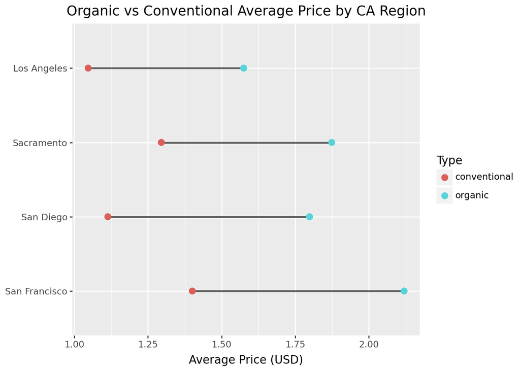

```python
import pandas as pd
from plotnine import *


pdf = price_diff.reset_index()
order = list(pdf.sort_values('diff', ascending=False)['california_regions'])
pdf['california_regions'] = pd.Categorical(pdf['california_regions'], categories=order, ordered=True)

long = pdf.melt(id_vars=['california_regions','diff'],
                value_vars=['conventional','organic'],
                var_name='type', value_name='avg_price')


(
    ggplot()
    + geom_segment(
        data=pdf,
        mapping=aes(y='california_regions', yend='california_regions',
                    x='conventional', xend='organic'),
        size=1, alpha=0.6
    )
    + geom_point(
        data=long,
        mapping=aes(y='california_regions', x='avg_price', color='type'),
        size=2.8
    )
    + labs(title='Organic vs Conventional Average Price by CA Region',
           x='Average Price (USD)', y='', color='Type')
    + theme(axis_text_y=element_text())
)
```

The lolipop chart shows the difference between conventional and organic by CA region where the largest distance between lolipops shows the highest difference being San Francisco.

# 8. Recreate Plot

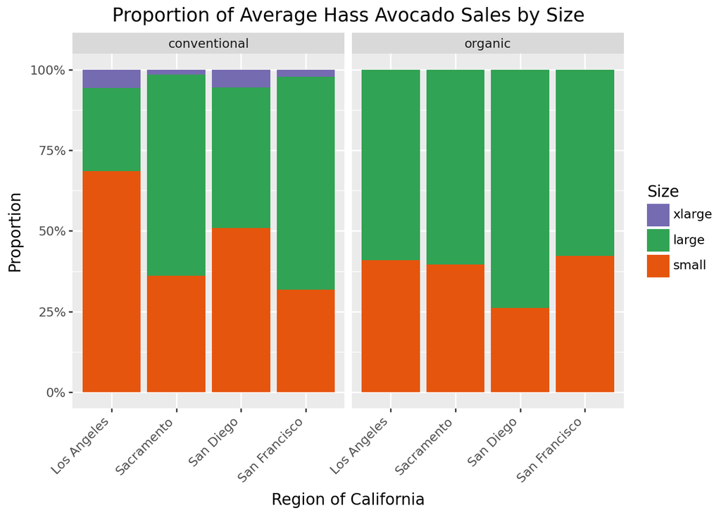

```python
df_8 = df_ca

size = df_8.groupby(['california_regions','type'], as_index=False)[
    ["size_xlarge","size_large","size_small"]
].mean()

long = size.melt(
    id_vars=["california_regions","type"],
    value_vars=["size_small","size_large","size_xlarge"],
    var_name="size", value_name="avg_sales"
)

order = ["size_xlarge","size_large","size_small"]
long["size"] = pd.Categorical(long["size"], categories=order, ordered=True)

(
    ggplot(long, aes(x='california_regions', y='avg_sales', fill='size'))
    + geom_col(position='fill')
    + facet_wrap('~type')
    + scale_y_continuous(labels=lambda v: [f'{x:.0%}' for x in v])
    + scale_fill_manual(
        values={
            "size_small":  "#E6550D",
            "size_large":  "#31A354",
            "size_xlarge": "#756BB1"
        },
        limits=order,
        labels=["xlarge","large","small"]
    )
    + labs(
        title='Proportion of Average Hass Avocado Sales by Size',
        x='Region of California',
        y='Proportion',
        fill='Size'
    )
    + theme(axis_text_x=element_text(rotation=45, ha='right'))
)
```

## Avocados and House Prices

```python
# Housing data from zillow
house = pd.read_csv("C:/Users/jonat/Documents/Calpoly MSBA/Fall/Machine Learning 544/Data/housing.csv")

#rename
house.rename(columns={'RegionID': "region_id", 'RegionName': "region_name", "Value": 'house_value'}, inplace=True)
house

house = house.melt(
    id_vars=["region_id", "region_name"],
    var_name="date",
    value_name="house_value"
)


# Convert Date column to datetime
house["date"] = pd.to_datetime(house["date"], errors="coerce")

# remove misc rows
house = house.dropna()

regions = [
    "Los Angeles",
    "San Francisco",
    "San Diego",
    "Sacramento"
]

house = house[house["region_name"].isin(regions)]


# remove na
house = house.dropna()

# reset index
house = house.reset_index()

# change type
house["house_value"] = house["house_value"].astype("float")
house.dtypes
house
```

|  | index | region_id | region_name | date | house_value |
| --- | --- | --- | --- | --- | --- |
| 0 | 128845 | 12447 | Los Angeles | 2000-01-31 | 220091.99 |
| 1 | 128852 | 54296 | San Diego | 2000-01-31 | 219248.79 |
| 2 | 128861 | 20330 | San Francisco | 2000-01-31 | 405811.45 |
| 3 | 128872 | 20288 | Sacramento | 2000-01-31 | 123200.35 |
| 4 | 150319 | 12447 | Los Angeles | 2000-02-29 | 220425.23 |
| ... | ... | ... | ... | ... | ... |
| 1569 | 6721379 | 20330 | San Francisco | 2025-08-31 | 1240382.01 |
| 1570 | 6721390 | 20288 | Sacramento | 2025-08-31 | 475952.06 |
| 1571 | 6728107 | 29290 | San Diego | 2025-08-31 | 87358.41 |
| 1572 | 6737477 | 54259 | Sacramento | 2025-08-31 | 132620.37 |
| 1573 | 6742356 | 13642 | Sacramento | 2025-08-31 | 243442.12 |

1574 rows × 5 columns

```python
#Adding housing to CA

combine = pd.merge(df_ca,house,how="inner", left_on=["date","california_regions"],right_on=["date","region_name"])

combine = combine[["date","california_regions","type","total_volume","average_price","house_value"]]

combine.head()
```

|  | date | california_regions | type | total_volume | average_price | house_value |
| --- | --- | --- | --- | --- | --- | --- |
| 0 | 2015-05-31 | Los Angeles | conventional | 3196936.02 | 0.85 | 515816.32 |
| 1 | 2015-05-31 | Los Angeles | organic | 44605.56 | 1.40 | 515816.32 |
| 2 | 2015-05-31 | Sacramento | conventional | 435723.85 | 1.17 | 245271.77 |
| 3 | 2015-05-31 | Sacramento | conventional | 435723.85 | 1.17 | 61507.65 |
| 4 | 2015-05-31 | Sacramento | organic | 10430.71 | 1.62 | 245271.77 |

Avacado prices should be higher as house value increases. This is because areas with higher house prices are expected to pay more for groceries.

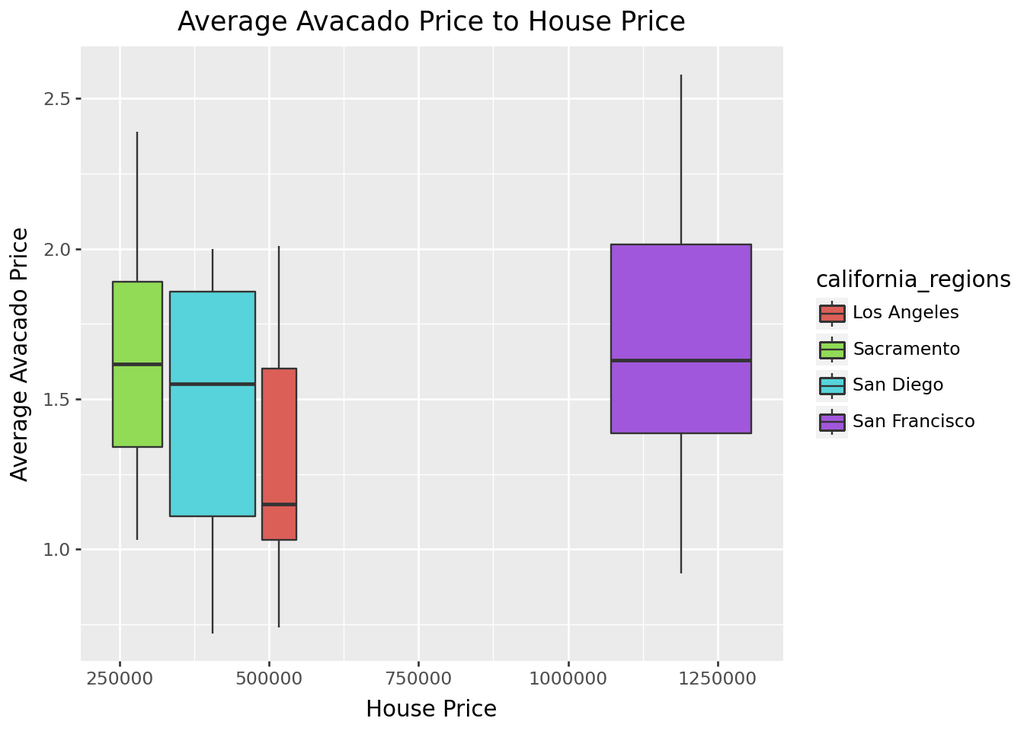

```python
# Box Plot
(
ggplot(combine, aes(x='house_value', y='average_price', fill='california_regions'))
 + geom_boxplot(aes(x="house_value",y="average_price"))
 + labs(x="House Price", y="Average Avacado Price", title="Average Avacado Price to House Price")
)
```

The boxplots show that average avacado price does not quite follow our expected postive linear relationship. Sacramento has the lowest housing price but average avacado price goes down around 500k house price. The avacado price then jumps up with a large difference in house prices of 1.25 million. The relationship is hard to make a definite association between house price and avacado price. It seems that Avacado price decreases for for houses 250k to 500k then increases afterward. This could represent a large gap in pricing for lower class vs upper class pricing.